# Week 6.3 - Using Regression Analysis to Test the Hot Hand

## Using Regression Analysis to Test the "Hot Hand"

In this section, we will use regression analysis to test for the "hot hand."

#### Import useful libraries and the shot log data

```python
import pandas as pd
import numpy as np
import datetime as dt
import statsmodels.formula.api as sm
import matplotlib.pyplot as plt
import seaborn as sns

Shotlog=pd.read_csv("../../Data/Week 6/Shotlog2.csv")
Player_Stats=pd.read_csv("../../Data/Week 6/Player_Stats2.csv")
Player_Shots=pd.read_csv("../../Data/Week 6/Player_Shots2.csv")
Shotlog.head()
```

|  | team_previous_shot | player_position | home_game | location_x | opponent_previous_shot | home_team | shot_type | points | away_team | location_y | ... | shoot_player | time_from_last_shot | quarter | current_shot_outcome | current_shot_hit | lag_shot_hit | average_hit | shot_count | shot_per_game | conse_shot_hit |
| --- | --- | --- | --- | --- | --- | --- | --- | --- | --- | --- | --- | --- | --- | --- | --- | --- | --- | --- | --- | --- | --- |
| 0 | MISSED | SF | Yes | 279.0 | SCORED | ATL | Jump Shot | 3 | WAS | 130.0 | ... | Kent Bazemore | 4.0 | 1 | MISSED | 0 | 0.0 | 0.408587 | 722 | 7 | 0 |
| 1 | MISSED | SF | Yes | 58.0 | SCORED | ATL | Cutting Layup Shot | 2 | WAS | 275.0 | ... | Kent Bazemore | 30.0 | 2 | MISSED | 0 | 0.0 | 0.408587 | 722 | 7 | 0 |
| 2 | SCORED | SF | Yes | 868.0 | SCORED | ATL | Jump Shot | 3 | WAS | 475.0 | ... | Kent Bazemore | 47.0 | 3 | MISSED | 0 | 0.0 | 0.408587 | 722 | 7 | 0 |
| 3 | SCORED | SF | Yes | 691.0 | MISSED | ATL | Pullup Jump Shot | 3 | WAS | 100.0 | ... | Kent Bazemore | 39.0 | 3 | SCORED | 1 | 0.0 | 0.408587 | 722 | 7 | 0 |
| 4 | MISSED | SF | Yes | 691.0 | MISSED | ATL | Pullup Jump Shot | 2 | WAS | 181.0 | ... | Kent Bazemore | 20.0 | 3 | MISSED | 0 | 1.0 | 0.408587 | 722 | 7 | 0 |

5 rows × 22 columns

### Prediction Error

Let's create a variable that equals to the difference between the outcome of the shot and the average success rate. Since we typically use the average success rate to predict the outcome of the shot, this difference will capture the prediction error.

```python
Shotlog['error']=Shotlog['current_shot_hit']-Shotlog['average_hit']
Shotlog['lagerror']=Shotlog['lag_shot_hit']-Shotlog['average_hit']
```

We can graph the outcome of the shots to see if there is any pattern over time in the variable.

We will look at LeBron James' performance during the regular season as an example.

```python
Shotlog['time'] = pd.to_timedelta(Shotlog['time'])
Shotlog['time'].describe()
```

```
count                    185052
mean     0 days 00:06:20.229465
std      0 days 00:03:23.013120
min             0 days 00:00:00
25%             0 days 00:03:30
50%             0 days 00:06:19
75%             0 days 00:09:14
max             0 days 00:12:00
Name: time, dtype: object
```

We will first graph the outcome of LeBron James' shots in a single game on April 9th, 2017.

(To make this graph, we use a small trick. Instead of asking Python to produce a scatter plot with the "plot.scatter" command, we ask Python to graph a line plot, but specify the width of the line to be 0. So essentially we produce a scatter plot. The reason we do it this way is because in Python, scatter plot requires the x axis to be numeric. It does not allow scatter plot where the x axis is a date or time variable.)

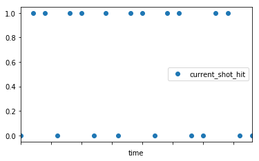

```python
Shotlog[(Shotlog.shoot_player == 'LeBron James')&(Shotlog.date=='2017-04-09')].plot(x='time', y='current_shot_hit', marker='o', linewidth=0)
```

Let's create a graph of the outcomes of individual shots for Lebron James throughout the regular season. We will create a subgraph for each game he played.

We will first subset a dataset that includes only LeBron James' data.

```python
LeBron_James=Shotlog[(Shotlog.shoot_player == 'LeBron James')]
LeBron_James.head()
```

|  | team_previous_shot | player_position | home_game | location_x | opponent_previous_shot | home_team | shot_type | points | away_team | location_y | ... | quarter | current_shot_outcome | current_shot_hit | lag_shot_hit | average_hit | shot_count | shot_per_game | conse_shot_hit | error | lagerror |
| --- | --- | --- | --- | --- | --- | --- | --- | --- | --- | --- | --- | --- | --- | --- | --- | --- | --- | --- | --- | --- | --- |
| 34019 | MISSED | SF | Yes | 236.0 | MISSED | CLE | Jump Shot | 3 | NYK | 84.0 | ... | 1 | MISSED | 0 | 1.0 | 0.547619 | 1344 | 14 | 0 | -0.547619 | 0.452381 |
| 34020 | BLOCKED | SF | Yes | 264.0 | SCORED | CLE | Jump Shot | 3 | NYK | 383.0 | ... | 1 | MISSED | 0 | 0.0 | 0.547619 | 1344 | 14 | 0 | -0.547619 | -0.547619 |
| 34021 | SCORED | SF | Yes | 50.0 | MISSED | CLE | Running Layup | 2 | NYK | 259.0 | ... | 1 | SCORED | 1 | 0.0 | 0.547619 | 1344 | 14 | 0 | 0.452381 | -0.547619 |
| 34022 | MISSED | SF | Yes | 52.0 | SCORED | CLE | Putback Dunk | 2 | NYK | 250.0 | ... | 1 | SCORED | 1 | 1.0 | 0.547619 | 1344 | 14 | 1 | 0.452381 | 0.452381 |
| 34023 | MISSED | SF | Yes | 52.0 | MISSED | CLE | Dunk | 2 | NYK | 250.0 | ... | 2 | SCORED | 1 | 1.0 | 0.547619 | 1344 | 14 | 1 | 0.452381 | 0.452381 |

5 rows × 24 columns

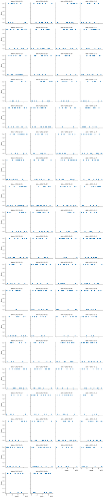

```python
g = sns.FacetGrid(LeBron_James, col="date", col_wrap=4)
g = g.map(plt.plot, "time", "current_shot_hit", marker='o', linewidth=0)
g.set_axis_labels("Game", "Shots");
```

We will do a similar exercise for the statistics of Cheick Diallo.

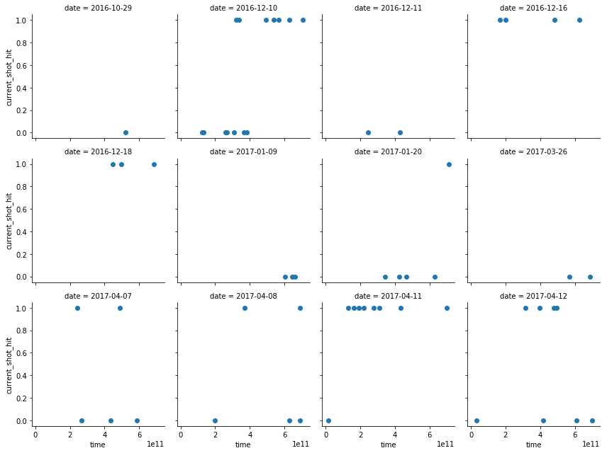

```python
Cheick_Diallo=Shotlog[(Shotlog.shoot_player == 'Cheick Diallo')]
g = sns.FacetGrid(Cheick_Diallo, col="date", col_wrap=4)
g = g.map(plt.plot, "time", "current_shot_hit", marker='o', linewidth=0)
```

## Self Test - 1

- Separate the shots by game
- Interpret your result

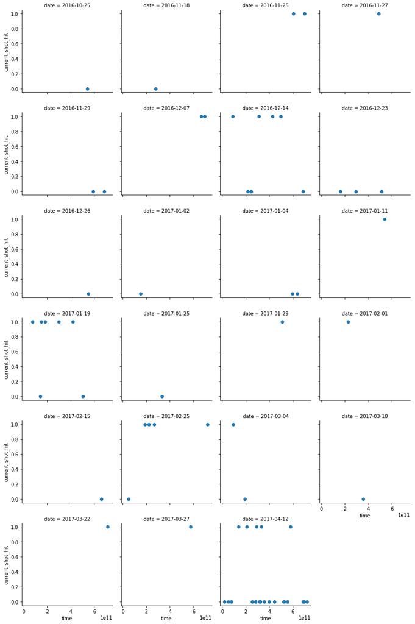

```python
#Your Code Here
James_Jones=Shotlog[(Shotlog.shoot_player == 'James Jones')]
jj_df = sns.FacetGrid(James_Jones, col="date", col_wrap=4)
jj_df = jj_df.map(plt.plot, "time", "current_shot_hit", marker='o', linewidth=0)
```

### Regression analysis on prediction error

We will first run a simple regression of the prediction error of current period on the prediction error of previous period.

```python
reg1 = sm.ols(formula = 'error ~ lagerror', data= Shotlog).fit()
print(reg1.summary())
```

```
                            OLS Regression Results
==============================================================================
Dep. Variable:                  error   R-squared:                       0.000
Model:                            OLS   Adj. R-squared:                  0.000
Method:                 Least Squares   F-statistic:                     71.65
Date:                Tue, 14 Feb 2023   Prob (F-statistic):           2.58e-17
Time:                        00:56:42   Log-Likelihood:            -1.3244e+05
No. Observations:              185052   AIC:                         2.649e+05
Df Residuals:                  185050   BIC:                         2.649e+05
Df Model:                           1
Covariance Type:            nonrobust
==============================================================================
                 coef    std err          t      P>|t|      [0.025      0.975]
------------------------------------------------------------------------------
Intercept      0.0018      0.001      1.589      0.112      -0.000       0.004
lagerror      -0.0196      0.002     -8.465      0.000      -0.024      -0.015
==============================================================================
Omnibus:                   661511.304   Durbin-Watson:                   2.001
Prob(Omnibus):                  0.000   Jarque-Bera (JB):            29292.756
Skew:                           0.163   Prob(JB):                         0.00
Kurtosis:                       1.078   Cond. No.                         2.02
==============================================================================

Warnings:
[1] Standard Errors assume that the covariance matrix of the errors is correctly specified.
```

*The estimated coefficient of the lagged error is statistically significant. However, the R-Squared for this regression is also zero. This means that our specified linear model is not a good fit for our data at all!*

There are a lot of factors that may influence the success of shot, for example, the player’s own skill as a shooter, the type of the shot, the atmosphere of the stadium (whether it is home or away game), and whether it is at the beginning or towards the end of the game. Let’s add these control variables in our regression.

```python
reg2 = sm.ols(formula = 'error ~ lagerror+player_position+home_game+opponent_previous_shot+C(points)+time_from_last_shot+C(quarter)', data= Shotlog).fit()
print(reg2.summary())
```

```
                            OLS Regression Results
==============================================================================
Dep. Variable:                  error   R-squared:                       0.015
Model:                            OLS   Adj. R-squared:                  0.015
Method:                 Least Squares   F-statistic:                     139.9
Date:                Tue, 14 Feb 2023   Prob (F-statistic):               0.00
Time:                        00:56:50   Log-Likelihood:            -1.2632e+05
No. Observations:              178281   AIC:                         2.527e+05
Df Residuals:                  178261   BIC:                         2.529e+05
Df Model:                          19
Covariance Type:            nonrobust
====================================================================================================
                                       coef    std err          t      P>|t|      [0.025      0.975]
----------------------------------------------------------------------------------------------------
Intercept                            0.0585      0.007      8.383      0.000       0.045       0.072
player_position[T.F]                 0.0251      0.007      3.860      0.000       0.012       0.038
player_position[T.G]                 0.0342      0.006      5.303      0.000       0.022       0.047
player_position[T.PF]                0.0214      0.004      5.162      0.000       0.013       0.029
player_position[T.PG]                0.0273      0.004      6.843      0.000       0.019       0.035
player_position[T.SF]                0.0352      0.004      8.491      0.000       0.027       0.043
player_position[T.SG]                0.0370      0.004      9.426      0.000       0.029       0.045
home_game[T.Yes]                     0.0118      0.002      5.068      0.000       0.007       0.016
opponent_previous_shot[T.MISSED]    -0.0130      0.006     -2.196      0.028      -0.025      -0.001
opponent_previous_shot[T.SCORED]    -0.0251      0.006     -4.276      0.000      -0.037      -0.014
C(points)[T.3]                      -0.1221      0.003    -47.641      0.000      -0.127      -0.117
C(quarter)[T.2]                     -0.0037      0.003     -1.069      0.285      -0.010       0.003
C(quarter)[T.3]                     -0.0117      0.003     -3.399      0.001      -0.018      -0.005
C(quarter)[T.4]                     -0.0079      0.003     -2.262      0.024      -0.015      -0.001
C(quarter)[T.5]                     -0.0633      0.015     -4.182      0.000      -0.093      -0.034
C(quarter)[T.6]                     -0.0461      0.044     -1.056      0.291      -0.132       0.039
C(quarter)[T.7]                     -0.1941      0.123     -1.579      0.114      -0.435       0.047
C(quarter)[T.8]                     -0.0194      0.116     -0.168      0.867      -0.247       0.208
lagerror                            -0.0136      0.002     -5.764      0.000      -0.018      -0.009
time_from_last_shot                 -0.0007    5.9e-05    -12.155      0.000      -0.001      -0.001
==============================================================================
Omnibus:                   668651.091   Durbin-Watson:                   2.001
Prob(Omnibus):                  0.000   Jarque-Bera (JB):            26177.325
Skew:                           0.153   Prob(JB):                         0.00
Kurtosis:                       1.148   Cond. No.                     4.09e+03
==============================================================================

Warnings:
[1] Standard Errors assume that the covariance matrix of the errors is correctly specified.
[2] The condition number is large, 4.09e+03. This might indicate that there are
strong multicollinearity or other numerical problems.
```

*We can see that the R-squared is now increased to 0.015 which is still very small. The estimate on lagerror is statistically significant, but the magnitude of the estimate is -0.0136 which is still very small. And it is negative, meaning that the success of the previous shot would hurt the chance of the subsequent shot. This is contrary to what the hot hand predicts.*

### Weighted least squares regression

As we have seen, some players had a lot of shot per game while some just had a few. Different players may have different variations in their success rate in the shots. We can run a weighted least squared regression to address this problem.

Weighted least squares estimation weights the observations proportional to the reciprocal of the error variance of the observation. Thus weighted least squares can overcome the issue of non-constant variance.

#### We can use the “sm.wls” command to run the weighted least square regression weighted by the number of shot per game (weight=1/shot_per_game).

```python
reg3 = sm.wls(formula = 'error ~ lagerror+player_position+home_game+opponent_previous_shot+points+time_from_last_shot+quarter',  weights=1/Shotlog['shot_per_game'] , data= Shotlog).fit()
print(reg3.summary())
```

```
                            WLS Regression Results
==============================================================================
Dep. Variable:                  error   R-squared:                       0.015
Model:                            WLS   Adj. R-squared:                  0.015
Method:                 Least Squares   F-statistic:                     209.7
Date:                Tue, 14 Feb 2023   Prob (F-statistic):               0.00
Time:                        00:56:55   Log-Likelihood:            -1.3913e+05
No. Observations:              178281   AIC:                         2.783e+05
Df Residuals:                  178267   BIC:                         2.784e+05
Df Model:                          13
Covariance Type:            nonrobust
====================================================================================================
                                       coef    std err          t      P>|t|      [0.025      0.975]
----------------------------------------------------------------------------------------------------
Intercept                            0.2997      0.009     34.069      0.000       0.282       0.317
player_position[T.F]                 0.0209      0.006      3.483      0.000       0.009       0.033
player_position[T.G]                 0.0355      0.006      6.275      0.000       0.024       0.047
player_position[T.PF]                0.0215      0.004      5.424      0.000       0.014       0.029
player_position[T.PG]                0.0233      0.004      5.791      0.000       0.015       0.031
player_position[T.SF]                0.0368      0.004      9.067      0.000       0.029       0.045
player_position[T.SG]                0.0350      0.004      8.946      0.000       0.027       0.043
home_game[T.Yes]                     0.0109      0.002      4.719      0.000       0.006       0.015
opponent_previous_shot[T.MISSED]    -0.0100      0.006     -1.694      0.090      -0.021       0.002
opponent_previous_shot[T.SCORED]    -0.0235      0.006     -4.026      0.000      -0.035      -0.012
lagerror                            -0.0128      0.002     -5.436      0.000      -0.017      -0.008
points                              -0.1244      0.003    -48.553      0.000      -0.129      -0.119
time_from_last_shot                 -0.0007   5.79e-05    -12.075      0.000      -0.001      -0.001
quarter                             -0.0019      0.001     -1.768      0.077      -0.004       0.000
==============================================================================
Omnibus:                  1601432.130   Durbin-Watson:                   2.000
Prob(Omnibus):                  0.000   Jarque-Bera (JB):            13896.376
Skew:                           0.178   Prob(JB):                         0.00
Kurtosis:                       1.680   Cond. No.                         367.
==============================================================================

Warnings:
[1] Standard Errors assume that the covariance matrix of the errors is correctly specified.
```

From our summary statistics, some players exhibit a stream of the success while some don’t. In our previous regressions, we are grouping all the players together. Let’s see if we can find any effect if we look at individual players.

#### Regression analysis on individual players

Run a regression of current error on lagged error for LeBron James.

```python
reg_LeBron = sm.ols(formula = 'error ~ lagerror+home_game+opponent_previous_shot+C(points)+time_from_last_shot+C(quarter)', data= LeBron_James).fit()
print(reg_LeBron.summary())
```

```
                            OLS Regression Results
==============================================================================
Dep. Variable:                  error   R-squared:                       0.060
Model:                            OLS   Adj. R-squared:                  0.051
Method:                 Least Squares   F-statistic:                     6.937
Date:                Tue, 14 Feb 2023   Prob (F-statistic):           1.89e-11
Time:                        00:56:55   Log-Likelihood:                -827.33
No. Observations:                1204   AIC:                             1679.
Df Residuals:                    1192   BIC:                             1740.
Df Model:                          11
Covariance Type:            nonrobust
====================================================================================================
                                       coef    std err          t      P>|t|      [0.025      0.975]
----------------------------------------------------------------------------------------------------
Intercept                            0.0640      0.089      0.720      0.472      -0.110       0.239
home_game[T.Yes]                     0.0383      0.028      1.359      0.174      -0.017       0.094
opponent_previous_shot[T.MISSED]     0.0403      0.083      0.489      0.625      -0.122       0.202
opponent_previous_shot[T.SCORED]     0.0456      0.083      0.552      0.581      -0.117       0.208
C(points)[T.3]                      -0.2554      0.033     -7.842      0.000      -0.319      -0.191
C(quarter)[T.2]                     -0.0098      0.041     -0.237      0.813      -0.091       0.071
C(quarter)[T.3]                     -0.0184      0.041     -0.451      0.652      -0.099       0.062
C(quarter)[T.4]                     -0.0102      0.043     -0.238      0.812      -0.094       0.074
C(quarter)[T.5]                     -0.2107      0.186     -1.132      0.258      -0.576       0.154
C(quarter)[T.6]                     -0.1632      0.282     -0.578      0.563      -0.717       0.391
lagerror                            -0.0160      0.028     -0.565      0.572      -0.071       0.039
time_from_last_shot                 -0.0009      0.001     -1.383      0.167      -0.002       0.000
==============================================================================
Omnibus:                     5847.508   Durbin-Watson:                   2.083
Prob(Omnibus):                  0.000   Jarque-Bera (JB):              154.298
Skew:                          -0.247   Prob(JB):                     3.12e-34
Kurtosis:                       1.317   Cond. No.                         825.
==============================================================================

Warnings:
[1] Standard Errors assume that the covariance matrix of the errors is correctly specified.
```

Similarly, we can run a weighted least squares estimation on LeBron James’ prediction error, weighted by the number of shot he made in each game.

```python
reg_LeBron_wls = sm.wls(formula = 'error ~ lagerror+home_game+opponent_previous_shot+points+time_from_last_shot+quarter',  weights=1/LeBron_James['shot_per_game'] , data= LeBron_James).fit()
print(reg_LeBron_wls.summary())
```

```
                            WLS Regression Results
==============================================================================
Dep. Variable:                  error   R-squared:                       0.066
Model:                            WLS   Adj. R-squared:                  0.061
Method:                 Least Squares   F-statistic:                     12.15
Date:                Tue, 14 Feb 2023   Prob (F-statistic):           4.63e-15
Time:                        00:56:56   Log-Likelihood:                -837.48
No. Observations:                1204   AIC:                             1691.
Df Residuals:                    1196   BIC:                             1732.
Df Model:                           7
Covariance Type:            nonrobust
====================================================================================================
                                       coef    std err          t      P>|t|      [0.025      0.975]
----------------------------------------------------------------------------------------------------
Intercept                            0.6629      0.109      6.093      0.000       0.449       0.876
home_game[T.Yes]                     0.0311      0.028      1.112      0.266      -0.024       0.086
opponent_previous_shot[T.MISSED]     0.0089      0.081      0.110      0.912      -0.149       0.167
opponent_previous_shot[T.SCORED]     0.0130      0.081      0.160      0.873      -0.146       0.172
lagerror                            -0.0099      0.028     -0.355      0.723      -0.065       0.045
points                              -0.2754      0.032     -8.540      0.000      -0.339      -0.212
time_from_last_shot                 -0.0011      0.001     -1.638      0.102      -0.002       0.000
quarter                             -0.0042      0.013     -0.318      0.750      -0.030       0.022
==============================================================================
Omnibus:                     6643.172   Durbin-Watson:                   2.079
Prob(Omnibus):                  0.000   Jarque-Bera (JB):              141.412
Skew:                          -0.257   Prob(JB):                     1.96e-31
Kurtosis:                       1.402   Cond. No.                         427.
==============================================================================

Warnings:
[1] Standard Errors assume that the covariance matrix of the errors is correctly specified.
```

We can also take a look back at LeBron James’ autocorrelation coefficient.

```python
Shotlog[(Shotlog.shoot_player == 'LeBron James')][['current_shot_hit','lag_shot_hit']].corr()
```

|  | current_shot_hit | lag_shot_hit |
| --- | --- | --- |
| current_shot_hit | 1.000000 | -0.033244 |
| lag_shot_hit | -0.033244 | 1.000000 |

*The autocorrelation coefficient between the outcomes of the current shot and the previous shot for LeBron James is very small.*

We can do a similar exercise for James Jones. We will start with an ordinary least square regression.

```python
reg_Jones = sm.ols(formula = 'error ~ lagerror+home_game+opponent_previous_shot+C(points)+time_from_last_shot+C(quarter)', data= James_Jones).fit()
print(reg_Jones.summary())
```

```
                            OLS Regression Results
==============================================================================
Dep. Variable:                  error   R-squared:                       0.101
Model:                            OLS   Adj. R-squared:                 -0.043
Method:                 Least Squares   F-statistic:                    0.7016
Date:                Tue, 14 Feb 2023   Prob (F-statistic):              0.705
Time:                        00:56:56   Log-Likelihood:                -43.888
No. Observations:                  66   AIC:                             107.8
Df Residuals:                      56   BIC:                             129.7
Df Model:                           9
Covariance Type:            nonrobust
====================================================================================================
                                       coef    std err          t      P>|t|      [0.025      0.975]
----------------------------------------------------------------------------------------------------
Intercept                            0.6448      0.411      1.570      0.122      -0.178       1.468
home_game[T.Yes]                    -0.2305      0.147     -1.568      0.122      -0.525       0.064
opponent_previous_shot[T.MISSED]     0.0274      0.283      0.097      0.923      -0.539       0.593
opponent_previous_shot[T.SCORED]    -0.0324      0.274     -0.118      0.907      -0.582       0.517
C(points)[T.3]                      -0.0792      0.133     -0.595      0.554      -0.346       0.187
C(quarter)[T.2]                     -0.3290      0.316     -1.040      0.303      -0.963       0.305
C(quarter)[T.3]                     -0.3385      0.312     -1.086      0.282      -0.963       0.286
C(quarter)[T.4]                     -0.4236      0.285     -1.485      0.143      -0.995       0.148
lagerror                             0.1355      0.137      0.992      0.326      -0.138       0.409
time_from_last_shot                 -0.0023      0.005     -0.491      0.625      -0.012       0.007
==============================================================================
Omnibus:                       85.183   Durbin-Watson:                   1.650
Prob(Omnibus):                  0.000   Jarque-Bera (JB):                7.056
Skew:                           0.258   Prob(JB):                       0.0294
Kurtosis:                       1.484   Cond. No.                         358.
==============================================================================

Warnings:
[1] Standard Errors assume that the covariance matrix of the errors is correctly specified.
```

We will also run a weighted least squares estimation on Jones' statistics. Weight=1/shot_per_game.

```python
reg_Jones_wls = sm.wls(formula = 'error ~ lagerror+home_game+opponent_previous_shot+points+time_from_last_shot+quarter',  weights=1/James_Jones['shot_per_game'] , data= James_Jones).fit()
print(reg_Jones_wls.summary())
```

```
                            WLS Regression Results
==============================================================================
Dep. Variable:                  error   R-squared:                       0.213
Model:                            WLS   Adj. R-squared:                  0.118
Method:                 Least Squares   F-statistic:                     2.244
Date:                Tue, 14 Feb 2023   Prob (F-statistic):             0.0433
Time:                        00:56:56   Log-Likelihood:                -53.746
No. Observations:                  66   AIC:                             123.5
Df Residuals:                      58   BIC:                             141.0
Df Model:                           7
Covariance Type:            nonrobust
====================================================================================================
                                       coef    std err          t      P>|t|      [0.025      0.975]
----------------------------------------------------------------------------------------------------
Intercept                            0.8315      0.601      1.384      0.172      -0.371       2.034
home_game[T.Yes]                    -0.2812      0.129     -2.184      0.033      -0.539      -0.023
opponent_previous_shot[T.MISSED]     0.3139      0.290      1.082      0.284      -0.267       0.895
opponent_previous_shot[T.SCORED]     0.1670      0.283      0.591      0.557      -0.399       0.733
lagerror                            -0.0545      0.133     -0.409      0.684      -0.321       0.212
points                               0.0680      0.135      0.503      0.617      -0.202       0.338
time_from_last_shot                 -0.0045      0.004     -1.098      0.277      -0.013       0.004
quarter                             -0.2484      0.077     -3.223      0.002      -0.403      -0.094
==============================================================================
Omnibus:                        4.529   Durbin-Watson:                   1.447
Prob(Omnibus):                  0.104   Jarque-Bera (JB):                2.383
Skew:                           0.198   Prob(JB):                        0.304
Kurtosis:                       2.158   Cond. No.                         475.
==============================================================================

Warnings:
[1] Standard Errors assume that the covariance matrix of the errors is correctly specified.
```

## Self Test - 2

Use regression analysis to test "hot hand" for Cheick Diallo

1. Run an ordinary least square regression of current error on lagged error for Cheick Diallo.
2. Run a weighted least sqaure regression of current error on lagged error for Cheick Diallo, weight=1/shot_per_game.
3. Interpret your regression results.

```python
#Your Code Here
reg_Diallo = sm.ols(formula = 'error ~ lagerror+home_game+opponent_previous_shot+C(points)+time_from_last_shot+C(quarter)', data= Cheick_Diallo).fit()
print(reg_Diallo.summary())
```

```
                            OLS Regression Results
==============================================================================
Dep. Variable:                  error   R-squared:                       0.114
Model:                            OLS   Adj. R-squared:                 -0.025
Method:                 Least Squares   F-statistic:                    0.8223
Date:                Tue, 14 Feb 2023   Prob (F-statistic):              0.587
Time:                        01:04:32   Log-Likelihood:                -39.875
No. Observations:                  60   AIC:                             97.75
Df Residuals:                      51   BIC:                             116.6
Df Model:                           8
Covariance Type:            nonrobust
====================================================================================================
                                       coef    std err          t      P>|t|      [0.025      0.975]
----------------------------------------------------------------------------------------------------
Intercept                           -0.3642      0.575     -0.634      0.529      -1.518       0.790
home_game[T.Yes]                    -0.2718      0.260     -1.047      0.300      -0.793       0.249
opponent_previous_shot[T.MISSED]     0.6567      0.562      1.169      0.248      -0.471       1.784
opponent_previous_shot[T.SCORED]     0.5878      0.561      1.047      0.300      -0.539       1.715
C(points)[T.3]                      -0.6745      0.544     -1.240      0.221      -1.767       0.418
C(quarter)[T.3]                     -0.0126      0.237     -0.053      0.958      -0.489       0.464
C(quarter)[T.4]                     -0.1200      0.174     -0.688      0.494      -0.470       0.230
lagerror                             0.1577      0.154      1.021      0.312      -0.152       0.468
time_from_last_shot                 -0.0026      0.004     -0.673      0.504      -0.010       0.005
==============================================================================
Omnibus:                      144.275   Durbin-Watson:                   1.924
Prob(Omnibus):                  0.000   Jarque-Bera (JB):                6.864
Skew:                          -0.161   Prob(JB):                       0.0323
Kurtosis:                       1.375   Cond. No.                         529.
==============================================================================

Warnings:
[1] Standard Errors assume that the covariance matrix of the errors is correctly specified.
```

```python
#Your Code Here
reg_Diallo_wls = sm.wls(formula = 'error ~ lagerror+home_game+opponent_previous_shot+points+time_from_last_shot+quarter',  weights=1/Cheick_Diallo['shot_per_game'] , data= Cheick_Diallo).fit()
print(reg_Diallo_wls.summary())
```

```
                            WLS Regression Results
==============================================================================
Dep. Variable:                  error   R-squared:                       0.129
Model:                            WLS   Adj. R-squared:                  0.011
Method:                 Least Squares   F-statistic:                     1.097
Date:                Tue, 14 Feb 2023   Prob (F-statistic):              0.379
Time:                        01:04:42   Log-Likelihood:                -43.257
No. Observations:                  60   AIC:                             102.5
Df Residuals:                      52   BIC:                             119.3
Df Model:                           7
Covariance Type:            nonrobust
====================================================================================================
                                       coef    std err          t      P>|t|      [0.025      0.975]
----------------------------------------------------------------------------------------------------
Intercept                            0.5633      1.125      0.501      0.619      -1.694       2.820
home_game[T.Yes]                    -0.2772      0.249     -1.114      0.271      -0.777       0.222
opponent_previous_shot[T.MISSED]     0.4394      0.794      0.553      0.583      -1.155       2.033
opponent_previous_shot[T.SCORED]     0.5962      0.795      0.750      0.456      -0.998       2.191
lagerror                             0.2141      0.151      1.420      0.161      -0.088       0.517
points                              -0.5207      0.383     -1.358      0.180      -1.290       0.249
time_from_last_shot                 -0.0015      0.004     -0.367      0.715      -0.010       0.007
quarter                              0.0011      0.089      0.012      0.990      -0.178       0.180
==============================================================================
Omnibus:                       45.352   Durbin-Watson:                   1.845
Prob(Omnibus):                  0.000   Jarque-Bera (JB):                5.286
Skew:                          -0.097   Prob(JB):                       0.0711
Kurtosis:                       1.559   Cond. No.                         765.
==============================================================================

Warnings:
[1] Standard Errors assume that the covariance matrix of the errors is correctly specified.
```

#### More generally, we can define functions to run regressions for each individual player.

- Define a function to run ordinary least square regression by player.

```python
def reg_player(player):
    Shotlog_player=Shotlog[Shotlog.shoot_player==player]
    reg_player=sm.ols(formula = 'error ~ lagerror+home_game+opponent_previous_shot+points+time_from_last_shot+quarter', data= Shotlog_player).fit()
    print(reg_player.summary())
    return;
```

We can then use this function for individual player, for example, Russell Westbrook.

```python
reg_player('Russell Westbrook')
```

```
                            OLS Regression Results
==============================================================================
Dep. Variable:                  error   R-squared:                       0.014
Model:                            OLS   Adj. R-squared:                  0.010
Method:                 Least Squares   F-statistic:                     3.740
Date:                Tue, 14 Feb 2023   Prob (F-statistic):           0.000498
Time:                        00:56:56   Log-Likelihood:                -1290.1
No. Observations:                1828   AIC:                             2596.
Df Residuals:                    1820   BIC:                             2640.
Df Model:                           7
Covariance Type:            nonrobust
====================================================================================================
                                       coef    std err          t      P>|t|      [0.025      0.975]
----------------------------------------------------------------------------------------------------
Intercept                            0.2233      0.086      2.608      0.009       0.055       0.391
home_game[T.Yes]                     0.0245      0.023      1.063      0.288      -0.021       0.070
opponent_previous_shot[T.MISSED]     0.0425      0.057      0.741      0.459      -0.070       0.155
opponent_previous_shot[T.SCORED]     0.0389      0.057      0.683      0.495      -0.073       0.151
lagerror                             0.0179      0.023      0.764      0.445      -0.028       0.064
points                              -0.1197      0.025     -4.786      0.000      -0.169      -0.071
time_from_last_shot                 -0.0004      0.001     -0.743      0.458      -0.002       0.001
quarter                              0.0046      0.010      0.439      0.661      -0.016       0.025
==============================================================================
Omnibus:                     7335.698   Durbin-Watson:                   2.020
Prob(Omnibus):                  0.000   Jarque-Bera (JB):              288.985
Skew:                           0.314   Prob(JB):                     1.77e-63
Kurtosis:                       1.156   Cond. No.                         353.
==============================================================================

Warnings:
[1] Standard Errors assume that the covariance matrix of the errors is correctly specified.
```

- Define a function to run weighted least square regression by player.

```python
def reg_wls_player(player):
    Shotlog_player=Shotlog[Shotlog.shoot_player==player]
    reg_wls_player=sm.wls(formula = 'error ~ lagerror+home_game+opponent_previous_shot+points+time_from_last_shot+quarter',weights=1/Shotlog_player['shot_per_game'] , data= Shotlog_player).fit()
    print(reg_wls_player.summary())
    return;
```

Let's use this function to run a weighted least squares estimation for Russell Westbrook.

```python
reg_wls_player('Russell Westbrook')
```

```
                            WLS Regression Results
==============================================================================
Dep. Variable:                  error   R-squared:                       0.014
Model:                            WLS   Adj. R-squared:                  0.010
Method:                 Least Squares   F-statistic:                     3.656
Date:                Tue, 14 Feb 2023   Prob (F-statistic):           0.000632
Time:                        00:56:57   Log-Likelihood:                -1325.2
No. Observations:                1828   AIC:                             2666.
Df Residuals:                    1820   BIC:                             2711.
Df Model:                           7
Covariance Type:            nonrobust
====================================================================================================
                                       coef    std err          t      P>|t|      [0.025      0.975]
----------------------------------------------------------------------------------------------------
Intercept                            0.2679      0.085      3.148      0.002       0.101       0.435
home_game[T.Yes]                     0.0311      0.023      1.353      0.176      -0.014       0.076
opponent_previous_shot[T.MISSED]    -0.0147      0.057     -0.258      0.797      -0.127       0.097
opponent_previous_shot[T.SCORED]    -0.0100      0.057     -0.176      0.860      -0.121       0.101
lagerror                             0.0276      0.023      1.175      0.240      -0.018       0.074
points                              -0.1164      0.025     -4.652      0.000      -0.166      -0.067
time_from_last_shot                 -0.0002      0.001     -0.340      0.734      -0.001       0.001
quarter                             -0.0006      0.011     -0.054      0.957      -0.021       0.020
==============================================================================
Omnibus:                     8079.619   Durbin-Watson:                   2.024
Prob(Omnibus):                  0.000   Jarque-Bera (JB):              262.634
Skew:                           0.328   Prob(JB):                     9.33e-58
Kurtosis:                       1.263   Cond. No.                         354.
==============================================================================

Warnings:
[1] Standard Errors assume that the covariance matrix of the errors is correctly specified.
```

#### We can extract estimated coefficient on the lagged error for each player.

- Create a list of unique player names

```python
player_list = np.array(Shotlog['shoot_player'])
player_list = np.unique(player_list)
```

```python
player_list[0]
```

```
'A.J. Hammons'
```

- Run weighted least squares regression for each player by specifying "shoot_play==player_list[index]"

```python
Shotlog_player=Shotlog[Shotlog.shoot_player==player_list[0]]
reg_player=sm.wls(formula = 'error ~ lagerror+home_game+opponent_previous_shot+points+time_from_last_shot+quarter', weights=1/Shotlog_player['shot_per_game'], data= Shotlog_player).fit()
print(reg_player.summary())
```

```
                            WLS Regression Results
==============================================================================
Dep. Variable:                  error   R-squared:                       0.410
Model:                            WLS   Adj. R-squared:                  0.233
Method:                 Least Squares   F-statistic:                     2.317
Date:                Tue, 14 Feb 2023   Prob (F-statistic):             0.0732
Time:                        00:56:57   Log-Likelihood:                -12.596
No. Observations:                  27   AIC:                             39.19
Df Residuals:                      20   BIC:                             48.26
Df Model:                           6
Covariance Type:            nonrobust
====================================================================================================
                                       coef    std err          t      P>|t|      [0.025      0.975]
----------------------------------------------------------------------------------------------------
Intercept                            0.2746      0.769      0.357      0.725      -1.330       1.880
home_game[T.Yes]                    -0.3026      0.205     -1.475      0.156      -0.731       0.125
opponent_previous_shot[T.SCORED]    -0.5703      0.249     -2.293      0.033      -1.089      -0.051
lagerror                             0.0900      0.208      0.433      0.670      -0.344       0.524
points                              -0.1527      0.243     -0.630      0.536      -0.659       0.353
time_from_last_shot                 -0.0033      0.007     -0.446      0.660      -0.019       0.012
quarter                              0.1643      0.107      1.539      0.140      -0.058       0.387
==============================================================================
Omnibus:                        1.251   Durbin-Watson:                   2.142
Prob(Omnibus):                  0.535   Jarque-Bera (JB):                1.186
Skew:                           0.429   Prob(JB):                        0.553
Kurtosis:                       2.437   Cond. No.                         336.
==============================================================================

Warnings:
[1] Standard Errors assume that the covariance matrix of the errors is correctly specified.
```

- Extract the estimated coefficients, along with the p-value and t-statistics of the estimates and store them in a dataframe

```python
RegParams = pd.DataFrame(reg_player.params).reset_index()
RegTvals = pd.DataFrame(reg_player.tvalues).reset_index()
RegPvals = pd.DataFrame(reg_player.pvalues).reset_index()

RegOutput = pd.merge(RegParams, RegTvals, on=['index'])
RegOutput = pd.merge(RegOutput, RegPvals, on=['index'])
RegOutput
```

|  | index | 0_x | 0_y | 0 |
| --- | --- | --- | --- | --- |
| 0 | Intercept | 0.274644 | 0.356938 | 0.724877 |
| 1 | home_game[T.Yes] | -0.302603 | -1.475049 | 0.155769 |
| 2 | opponent_previous_shot[T.SCORED] | -0.570258 | -2.292908 | 0.032826 |
| 3 | lagerror | 0.090024 | 0.432869 | 0.669742 |
| 4 | points | -0.152748 | -0.629826 | 0.535938 |
| 5 | time_from_last_shot | -0.003295 | -0.446319 | 0.660162 |
| 6 | quarter | 0.164321 | 1.538863 | 0.139510 |

- Write a loop to extract regression outputs for each player

```python
i = 0
Player_Results = {}
while i <= len(player_list) - 1:
    Shotlog_player=Shotlog[Shotlog.shoot_player==player_list[i]]
    reg_player=sm.wls(formula = 'error ~ lagerror+home_game+opponent_previous_shot+points+time_from_last_shot+quarter', weights=1/Shotlog_player['shot_per_game'], data= Shotlog_player).fit()
    RegParams = pd.DataFrame(reg_player.params).reset_index()
    RegTvals = pd.DataFrame(reg_player.tvalues).reset_index()
    RegPvals = pd.DataFrame(reg_player.pvalues).reset_index()

    RegOutput = pd.merge(RegParams, RegTvals, on=['index'])
    RegOutput = pd.merge(RegOutput, RegPvals, on=['index'])
    RegOutput

    LagErr = RegOutput[RegOutput['index'] == 'lagerror']
    LagErr = LagErr.drop(columns=['index'])
    LagErr = LagErr.rename(columns={"0_x":"Coef", "0_y":"T_Statistics", 0:"P_Value"})
    LagErr['shoot_player'] = player_list[i]
    Headers = ['shoot_player', 'Coef', 'T_Statistics', 'P_Value']
    Player_Results[i] = LagErr[Headers]
    i = i+1
```

- Write another loop to build a dataframe to store the regression output for all the players

```python
RegPlayer = Player_Results[0]
j = 1
while j <= len(player_list) - 1:
    RegPlayer = RegPlayer.append(Player_Results[j])
    j = j+1
RegPlayer = RegPlayer.reset_index()
RegPlayer = RegPlayer.drop(columns=['index'])
RegPlayer
```

|  | shoot_player | Coef | T_Statistics | P_Value |
| --- | --- | --- | --- | --- |
| 0 | A.J. Hammons | 0.090024 | 0.432869 | 0.669742 |
| 1 | Aaron Brooks | -0.038379 | -0.577078 | 0.564466 |
| 2 | Aaron Gordon | -0.003899 | -0.110137 | 0.912330 |
| 3 | Adreian Payne | -0.323775 | -2.017711 | 0.052349 |
| 4 | Al Horford | -0.031727 | -0.851036 | 0.395038 |
| 5 | Al Jefferson | -0.138732 | -2.671595 | 0.007888 |
| 6 | Al-Farouq Aminu | 0.049489 | 0.970895 | 0.332225 |
| 7 | Alan Anderson | -0.052401 | -0.359471 | 0.721044 |
| 8 | Alan Williams | -0.100764 | -1.498815 | 0.135395 |
| 9 | Alec Burks | -0.009769 | -0.134655 | 0.893026 |
| 10 | Alex Abrines | 0.111870 | 1.873195 | 0.062185 |
| 11 | Alex Len | -0.033125 | -0.639153 | 0.523130 |
| 12 | Alex Poythress | 0.119004 | 0.753972 | 0.455394 |
| 13 | Alexis Ajinca | 0.001526 | 0.017245 | 0.986268 |
| 14 | Allen Crabbe | -0.015048 | -0.345306 | 0.730001 |
| 15 | Alonzo Gee | 0.594937 | 0.000000 | NaN |
| 16 | Amir Johnson | 0.107613 | 1.835580 | 0.067515 |
| 17 | Anderson Varejao | -0.740540 | -0.000000 | NaN |
| 18 | Andre Drummond | 0.020230 | 0.580712 | 0.561597 |
| 19 | Andre Iguodala | 0.028134 | 0.533794 | 0.593856 |
| 20 | Andre Roberson | -0.018510 | -0.378755 | 0.705089 |
| 21 | Andrew Bogut | 0.065470 | 0.416692 | 0.678842 |
| 22 | Andrew Harrison | -0.080738 | -1.362191 | 0.174261 |
| 23 | Andrew Nicholson | -0.101418 | -0.892269 | 0.375442 |
| 24 | Andrew Wiggins | -0.022509 | -0.861118 | 0.389316 |
| 25 | Anthony Bennett | 0.166642 | 1.374348 | 0.174362 |
| 26 | Anthony Brown | 0.061274 | 0.368053 | 0.715418 |
| 27 | Anthony Davis | -0.069182 | -2.629957 | 0.008632 |
| 28 | Anthony Morrow | -0.148779 | -2.181863 | 0.030334 |
| 29 | Anthony Tolliver | 0.013479 | 0.221540 | 0.824842 |
| ... | ... | ... | ... | ... |
| 451 | Trey Burke | -0.138801 | -1.944525 | 0.053357 |
| 452 | Trey Lyles | -0.055505 | -1.028838 | 0.304264 |
| 453 | Tristan Thompson | 0.009546 | 0.175707 | 0.860628 |
| 454 | Troy Daniels | -0.018100 | -0.360638 | 0.718559 |
| 455 | Troy Williams | -0.081274 | -0.942169 | 0.347968 |
| 456 | Ty Lawson | -0.033151 | -0.699612 | 0.484547 |
| 457 | Tyler Ennis | -0.069754 | -0.912791 | 0.362817 |
| 458 | Tyler Johnson | -0.071963 | -1.945650 | 0.052087 |
| 459 | Tyler Ulis | -0.058429 | -1.146834 | 0.252208 |
| 460 | Tyler Zeller | 0.078852 | 0.775253 | 0.440019 |
| 461 | Tyreke Evans | -0.064237 | -1.125208 | 0.261371 |
| 462 | Tyson Chandler | -0.072320 | -0.934213 | 0.351511 |
| 463 | Tyus Jones | 0.072770 | 0.785837 | 0.433552 |
| 464 | Udonis Haslem | 0.429254 | 1.428814 | 0.196124 |
| 465 | Victor Oladipo | -0.037665 | -1.065624 | 0.286913 |
| 466 | Vince Carter | 0.011381 | 0.226437 | 0.820982 |
| 467 | Wade Baldwin IV | -0.132962 | -1.212127 | 0.229123 |
| 468 | Walter Tavares | 0.003626 | 0.000000 | NaN |
| 469 | Wayne Ellington | -0.054021 | -1.165489 | 0.244432 |
| 470 | Wayne Selden | -0.182914 | -1.312031 | 0.197381 |
| 471 | Wesley Johnson | -0.331181 | -3.869044 | 0.000175 |
| 472 | Wesley Matthews | -0.084057 | -2.320181 | 0.020599 |
| 473 | Will Barton | -0.010443 | -0.252440 | 0.800791 |
| 474 | Willie Cauley-Stein | -0.038517 | -0.764068 | 0.445284 |
| 475 | Willie Reed | -0.011248 | -0.161203 | 0.872095 |
| 476 | Wilson Chandler | -0.040719 | -1.192049 | 0.233582 |
| 477 | Yogi Ferrell | -0.053431 | -0.972739 | 0.331398 |
| 478 | Zach LaVine | -0.017180 | -0.432123 | 0.665803 |
| 479 | Zach Randolph | 0.015621 | 0.450958 | 0.652138 |
| 480 | Zaza Pachulia | -0.048359 | -0.712459 | 0.476925 |

481 rows × 4 columns

- Merge the total number of shots captured in "Player_Shots" to the regression result dataframe. This total number of shots represents the sample size of each regression

```python
RegPlayer=pd.merge(RegPlayer, Player_Shots, on=['shoot_player'])
RegPlayer.head()
```

|  | shoot_player | Coef | T_Statistics | P_Value | shot_count | avg_shot_game |
| --- | --- | --- | --- | --- | --- | --- |
| 0 | A.J. Hammons | 0.090024 | 0.432869 | 0.669742 | 42 | 2.800000 |
| 1 | Aaron Brooks | -0.038379 | -0.577078 | 0.564466 | 300 | 4.838710 |
| 2 | Aaron Gordon | -0.003899 | -0.110137 | 0.912330 | 864 | 10.800000 |
| 3 | Adreian Payne | -0.323775 | -2.017711 | 0.052349 | 54 | 3.600000 |
| 4 | Al Horford | -0.031727 | -0.851036 | 0.395038 | 801 | 11.779412 |

- Display players with statistically significant estimates on the lagged error variable

```python
display(RegPlayer.loc[RegPlayer['P_Value']<=0.05])
```

|  | shoot_player | Coef | T_Statistics | P_Value | shot_count | avg_shot_game |
| --- | --- | --- | --- | --- | --- | --- |
| 5 | Al Jefferson | -0.138732 | -2.671595e+00 | 7.888310e-03 | 471 | 7.246154 |
| 27 | Anthony Davis | -0.069182 | -2.629957e+00 | 8.632447e-03 | 1525 | 20.333333 |
| 28 | Anthony Morrow | -0.148779 | -2.181863e+00 | 3.033403e-02 | 251 | 5.340426 |
| 46 | Boris Diaw | 0.158741 | 2.530215e+00 | 1.204544e-02 | 327 | 4.671429 |
| 103 | DeAndre Liggins | -0.257574 | -2.468259e+00 | 1.558089e-02 | 142 | 3.021277 |
| 137 | Elijah Millsap | -0.037456 | -8.935839e+12 | 7.124343e-14 | 7 | 3.500000 |
| 146 | Frank Kaminsky | 0.086975 | 2.306844e+00 | 2.136766e-02 | 802 | 10.693333 |
| 174 | Isaiah Thomas | -0.073223 | -2.697235e+00 | 7.078367e-03 | 1473 | 19.381579 |
| 197 | Jared Dudley | -0.205050 | -3.462836e+00 | 6.241124e-04 | 346 | 5.580645 |
| 204 | Jason Terry | -0.183497 | -2.442365e+00 | 1.573796e-02 | 243 | 3.375000 |
| 217 | Joe Harris | -0.150670 | -2.631296e+00 | 8.954691e-03 | 362 | 6.961538 |
| 220 | Joe Young | 0.576458 | 3.086945e+00 | 3.713243e-03 | 72 | 2.769231 |
| 241 | Jose Calderon | 0.215926 | 2.110305e+00 | 3.777123e-02 | 134 | 3.621622 |
| 246 | Juancho Hernangomez | -0.175414 | -2.270396e+00 | 2.450133e-02 | 223 | 4.551020 |
| 251 | Justin Holiday | -0.113967 | -2.415070e+00 | 1.615044e-02 | 538 | 6.560976 |
| 265 | Kevin Love | -0.077740 | -2.164096e+00 | 3.076020e-02 | 867 | 14.450000 |
| 275 | Kyle Korver | -0.134847 | -2.795064e+00 | 5.426807e-03 | 514 | 7.671642 |
| 278 | Kyle Singler | -0.327411 | -2.230087e+00 | 3.045299e-02 | 83 | 3.192308 |
| 279 | Kyle Wiltjer | 1.000000 | 6.791844e+14 | 9.373298e-16 | 14 | 1.750000 |
| 285 | Langston Galloway | -0.100902 | -2.148476e+00 | 3.223123e-02 | 545 | 7.569444 |
| 313 | Marquese Chriss | -0.140440 | -3.414176e+00 | 6.889216e-04 | 632 | 7.802469 |
| 350 | Nikola Mirotic | -0.091055 | -2.157452e+00 | 3.142518e-02 | 624 | 8.914286 |
| 357 | Omri Casspi | 0.202156 | 2.175880e+00 | 3.164640e-02 | 165 | 4.583333 |
| 388 | Robert Covington | 0.079845 | 2.046637e+00 | 4.110690e-02 | 733 | 10.940299 |
| 428 | Taurean Prince | -0.176028 | -2.673040e+00 | 8.098857e-03 | 286 | 5.500000 |
| 437 | Tim Frazier | -0.134302 | -2.448189e+00 | 1.489937e-02 | 404 | 6.412698 |
| 446 | Tony Parker | 0.113212 | 2.503355e+00 | 1.263188e-02 | 569 | 9.031746 |
| 471 | Wesley Johnson | -0.331181 | -3.869044e+00 | 1.749226e-04 | 200 | 3.225806 |
| 472 | Wesley Matthews | -0.084057 | -2.320181e+00 | 2.059892e-02 | 847 | 11.602740 |

```python
#Save updated data to csv file
Shotlog.to_csv("../../Data/Week 6/Shotlog3.csv")
Player_Stats.to_csv("../../Data/Week 6/Player_Stats3.csv", index=False)
Player_Shots.to_csv("../../Data/Week 6/Player_Shots3.csv", index=False)
```